# Nahsime Bahmanian: Missing Verb Illusion

RePsychLing SMLP2022

Author

Reinhold Kliegl

Published

September 2, 2022

# 1 WORK IN PROGRESS

Script to analyze the number agreement errors made by Spanish native speakers in a web-based pronoun production experiment (Experiment 1: number agreement). Created May 2022, by Sol Lago and Nasimeh Bahmanian.

# 2 Modeling issues

In the majority of the models, we had to simplify due to convergence issues. But even in the simplified models, we are facing singularity issue. I know that we should not simply ignore singularity warnings, but we decided not to simplify our models further. So, in addition to how to resolve convergence issues without oversimplifying a model, I would like to discuss singularity during the summer school and better understand the consequences of ignoring it.

# 3 Background

In this experiment participants were asked to describe scenes of moving objects by producing sentences (in Spanish) like the English example below:

```
   *The shield(s)* pipped  *the hat(s)*  below/above    *it/them*
    antecedent              attractor                    pronoun
```

The antecedent and the attractor either matched or mismatched in number. We are interested to see if responses in mismatch conditions differs from match conditions (1) in terms of accuracy, i.e. whether participants made agreement errors in producing the pronoun. (2) in term of latency in planning/production of the pronoun in error-free responses. For the latter, we are looking at the duration of critical regions as well as the likelihood of a non-zero pause immediately before the critical region.

# 4 ReadME

Some of the variables

- ‘TargetResponseIdentical’
- ‘ResponseComplete’
- ‘NumberError’
- ‘GenderError’
- ‘OtherDifferences’

are only needed to create the two dataframes: accuracy data and latency data.

For the stat, depending on the analysis, I need different sets of variables:

- Analysis of errors
  - ‘NumberError’
  - ‘Match’
  - ‘AntecedentNumber’
- Analysis of pauses
  - ‘Segment’
  - ‘Pause’
  - ‘Match’
  - ‘AntecedentNumber’
- Analysis of durations
  - ‘Segment’
  - ‘Duration’
  - ‘Match’
  - ‘AntecedentNumber’
  - ‘Structure’
  - ‘Syllable’
  - ‘NounGender’

# 5 Setup

```r
#library(summarytools)                   # data frame visualization and summary
library(binom)                          # binomial confidence intervals
library(tidyverse)                      # data manipulation and plotting
library(ggridges)                       # density plots
library(scales)                         # scales for plots
library(patchwork)                      # concatenate plots
#library(lmerTest)                       # frequentist stats
library(lme4)
library(car)                            # plot residuals
library(MASS)                           # boxcox
library(Hmisc)                          # descriptive statistics
library(OneR)                           # vincentile
```

# 6 Preprocessing

## 6.1 Trials to exclude from the accuracy analysis.

```r
EXCLUDE_ACCURACY <- c("wrong_word", "wrong_number",
                      "pronoun_unintelligible", "other")
```

## 6.2 Number of vincentiles for vincentile plot.

```r
N_VINCENTILES <- 6
```

## 6.3 Import data

```r
productiondata  <- read.table("./data/results_experiment1_long.csv",
                          sep = ",",
                          stringsAsFactors = TRUE,
                          header = TRUE,
                          quote = "'")

productiondata$Item <- factor(productiondata$Item)
```

## 6.4 Create data frame for accuracy analysis

```r
accuracydata <-
  mutate(productiondata) %>%
  # Keep one row per trial.
  dplyr::select(!("Segment":"Syllable")) %>%
  unique() %>%
  # Exclude incomplete responses.
  filter(ResponseComplete == "yes") %>%
  # Exclude responses with gender errors or distorted preambles.
  filter(!(GenderError %in% c("yes"))) %>%
  filter(!(OtherDifferences %in% EXCLUDE_ACCURACY)) %>%
  # Convert number errors to a numeric variable (0 = correct; 1 = error).
  mutate(NumberError = ifelse(NumberError == "no", 0, 1)) %>%
  # Re-order factor levels.
  mutate(Condition = factor(Condition, levels = c("ss", "sp", "pp", "ps"))) %>%
  mutate(AntecedentNumber = factor(AntecedentNumber, levels = c("singular", "plural"))) %>%
  droplevels()
```

## 6.5 Create data frame for latency analysis

```r
latencydata <- mutate(productiondata) %>%

  # Exclude incomplete responses.
  filter(ResponseComplete == "yes") %>%

  # Exclude responses that are not identical to the target sentences.
  filter(TargetResponseIdentical == TRUE) %>%

  # Re-order factor levels.
  mutate(Condition = factor(Condition, levels = c("ss", "sp", "pp", "ps"))) %>%
  mutate(AntecedentNumber = factor(AntecedentNumber, levels = c("singular", "plural"))) %>%
  mutate(Segment = factor(Segment, levels = c("onset",
                                              "antecedent",
                                              "verb",
                                              "attractor",
                                              "adverb",
                                              "pronoun",
                                              "attractor_pronoun"))) %>%
  droplevels()
```

## 6.6 Outlier exclusions for latency data

Outlier detection is done using the IQR method described [here](https://statsandr.com/blog/outliers-detection-in-r/).

According to this method, outliers are all observations above Q75 + 1.5 IQR or below Q25 - 1.5 IQR (where Q25 and Q75 correspond to the first and third quartile, and IQR is the difference between them).

## 6.7 Visualize outliers according to the IQR method.

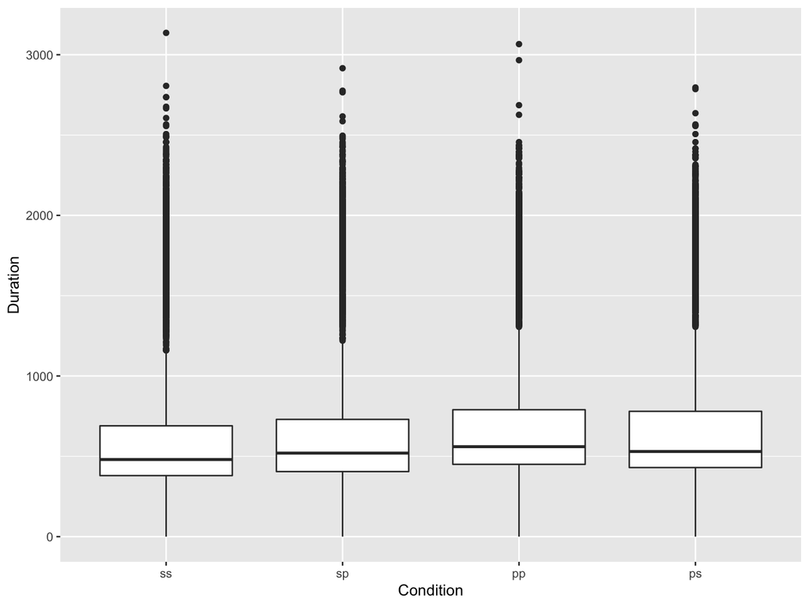

```r
ggplot(latencydata, aes(x = Condition, y = Duration)) + geom_boxplot()
```

## 6.8 Compute outlier bounds per segment

```r
outliers_iqr <- latencydata %>%
  group_by(Segment) %>%
  summarise(
    Qlow       = quantile(Duration, probs = 0.25),
    Qup        = quantile(Duration, probs = 0.75),
    Iqr        = Qup - Qlow,
    LowerBound = Qlow - 1.5 * Iqr,
    UpperBound = Qup + 1.5 * Iqr
  )
```

## 6.9 Replace outliers with NAs in latency data

```r
latencydata <-
  latencydata  %>%

  # Add exclusion criterion to the latency data.
  left_join(dplyr::select(outliers_iqr, c(Segment, LowerBound, UpperBound))) %>%

  # Revise durations: outliers replaced with NA.
  mutate(Duration = ifelse(Duration < LowerBound | Duration > UpperBound, NA, Duration)) %>%

  # Revise pauses: pause is NA when duration is NA.
  mutate(Pause = ifelse(is.na(Duration), NA, Pause)) %>%

  # Delete lower- and upper-bound columns.
  dplyr::select(-c(LowerBound, UpperBound))
```

## 6.10 Quantify exclusion rates per segment

```r
outlier_exclusions <-
  latencydata %>%

  # Group by segment.
  group_by(Segment, Condition) %>%

  # Compute averages.
  summarise(
    NExcluded       = length(Duration[is.na(Duration)]),
    NTrial          = length(Duration),
    PercentExcluded = NExcluded / NTrial * 100)
```

Print to screen.

```r
print(outlier_exclusions, n = 30)
```

```
# A tibble: 28 × 5
# Groups:   Segment [7]
   Segment           Condition NExcluded NTrial PercentExcluded
   <fct>             <fct>         <int>  <int>           <dbl>
 1 onset             ss               41   1115           3.68
 2 onset             sp               27   1015           2.66
 3 onset             pp               24   1023           2.35
 4 onset             ps               18    998           1.80
 5 antecedent        ss               97   1115           8.70
 6 antecedent        sp              100   1015           9.85
 7 antecedent        pp               92   1023           8.99
 8 antecedent        ps               83    998           8.32
 9 verb              ss               30   1115           2.69
10 verb              sp               18   1015           1.77
11 verb              pp               36   1023           3.52
```

[output cut: 17 more lines]

## 6.11 Error rates by condition

```r
average_errors <- mutate(accuracydata) %>%
  group_by(Condition) %>%
  dplyr::summarise(
    .groups = "keep",
    NError = sum(NumberError),
    N      = length(NumberError),
    Mean   = NError / N * 100,
    CIlow  = as.numeric(binom.confint(NError, N, methods = "agresti-coull")["lower"]) * 100,
    CIhigh = as.numeric(binom.confint(NError, N, methods = "agresti-coull")["upper"]) * 100
    )
```

# 7 Plots

## 7.1 Condition

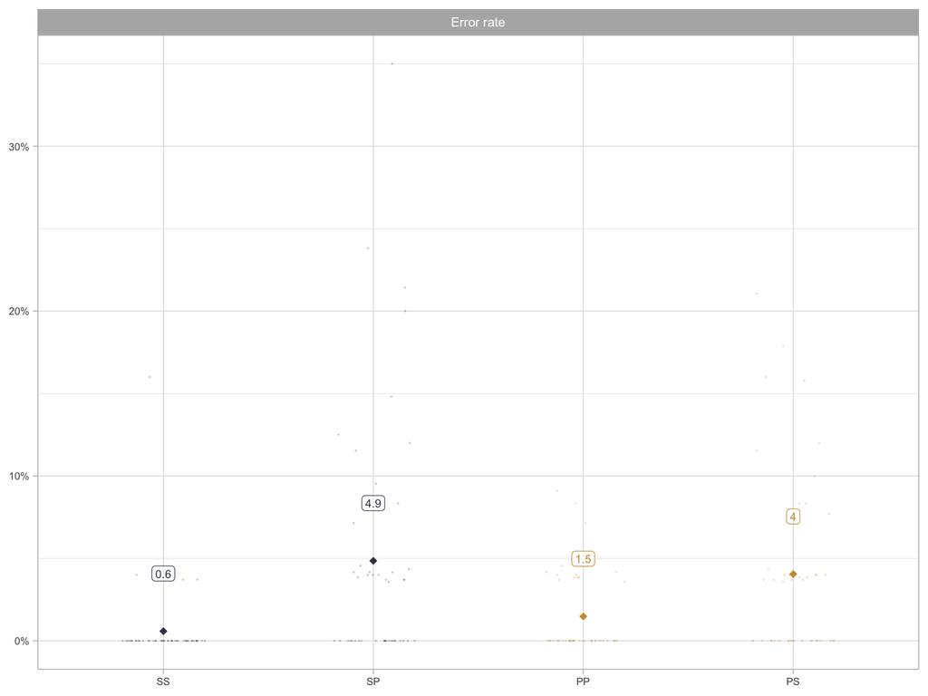

```r
jitter         <- position_jitter(width = 0.2, height = 0, seed = 0)
antecedent_col <- c("#3C425A", "#CC9A41")
facet_names    <- c(`experiment1` = "Error rate")

plot_errors <-
  accuracydata %>%

  # Compute mean error rates by participant.
  group_by(Experiment, Participant, Condition, AntecedentNumber) %>%
  summarise(.groups = "keep",
            NError = sum(NumberError),
            N      = length(NumberError),
            Mean   = NError / N) %>%

  # Add by-condition means to the data frame.
  group_by(Condition) %>%
  mutate(MeanCondition = mean(Mean, na.rm = TRUE)) %>%

  # Draw plot.
  {ggplot(., aes(x = Condition, y = Mean, color = AntecedentNumber)) +

      # Draw by-participant means.
      geom_point(size = 0.6, alpha = 0.3, stroke = 0, position = jitter) +

      # Draw group means and labels.
      stat_summary(fun = mean, geom = "point", shape = 18, size = 2)  +
      geom_label(
        data = unique(dplyr::select(., c(Condition, MeanCondition, AntecedentNumber))),
        aes(x = Condition, y = MeanCondition, label = round(MeanCondition, 3) * 100),
        size = 2.5, nudge_y = 0.035, label.padding = unit(.15, "lines"),
        label.size = 0.2, alpha = 0.5) +

      # Create a facet title..
      facet_wrap(. ~ Experiment, scales = "free", labeller = as_labeller(facet_names)) +

      # Customize axes and scales.
      labs(x = NULL, y = NULL) +
      scale_color_manual(values = antecedent_col) +
      scale_x_discrete(labels = c("SS", "SP", "PP", "PS")) +
      scale_y_continuous(labels = scales::percent_format(accuracy = 1)) +

      # Customize theme.
      theme_light() +
      theme(legend.position = "none") +
      theme(text = element_text(size = 8, colour = "gray28")) +
      theme(strip.text.x = element_text(size = 8))
  }

plot_errors
```

```r
# Save plot.
# ggsave("./figureserror_rates.jpeg", plot_errors, units = "cm", height = 5, width = 5, dpi = 300)
```

## 7.2 Average durations

```r
average_duration <-
  latencydata %>%

  # Compute averages by condition and segment.
  group_by(Segment, AntecedentNumber, Match) %>%
  dplyr::summarise(
    .groups = "keep",
    N      = length(Duration),
    Mean   = mean(Duration, na.rm = TRUE),
    SD     = sd(Duration, na.rm = TRUE),
    CIlow  = Mean - (qnorm(0.975) * SD / sqrt(N)),
    CIhigh = Mean + (qnorm(0.975) * SD / sqrt(N)),
    )
```

## 7.3 Parameters

```r
jitter        <- position_jitter(width = 0.2, height = 0, seed = 0)
dodge         <- position_dodge(0.35)
color_cond    <- c("#3C425A", "#3C425A", "#CC9A41", "#CC9A41")
linetype_cond <- c("solid", "dotdash", "solid", "dotdash")
label_cond    <- toupper(levels(latencydata$Condition))
label_regions <- c("El escudo\nantecedent",
                   "ha pipeado\nverb",
                   "los sombreros\nattractor",
                   expression(~bold("(de) debajo\nadverb")),
                   expression(~bold("de él\npronoun")))
```

## 7.4 Sentence regions

```r
plot_duration_all <-
  latencydata %>%

  # Exclude utterance onset.
  filter(!Segment %in% c("onset", "attractor_pronoun")) %>%

  # Separate critical region from other segments.
  mutate(SegmentType = factor("All regions")) %>%

  # Compute mean durations by participant.
  group_by(Participant, SegmentType, Segment, Condition, AntecedentNumber, Match) %>%
  summarise(.groups = "keep", Mean = mean(Duration, na.rm = TRUE)) %>%

  # Draw plot.
  {ggplot(., aes(x = Segment, y = Mean, group = Condition, color = Condition)) +

      # Plot by-condition means and standard error bars.
      stat_summary(fun = mean, geom = "path", aes(linetype = Condition),
                   size = 0.5, position = dodge, na.rm = TRUE)  +
      stat_summary(fun.data = mean_se, geom = "errorbar", size = 0.5,
                   width = 0, position = dodge, show.legend = FALSE) +
      stat_summary(fun = mean, geom = "point", shape = 18, size = 2,
                   position = dodge, show.legend = FALSE)  +

      # Place utterance onset and sentence segments in different facets.
      facet_grid( ~ SegmentType) +

      # Customize axes and scales.
      labs(x = NULL, y = "Duration [ms]") +
      scale_x_discrete(labels = label_regions) +
      scale_color_manual(values = color_cond, labels = label_cond) +
      scale_linetype_manual(values = linetype_cond, labels = label_cond) +

      # Customize theme.
      theme_light() +
      theme(legend.position = "top") +
      theme(text = element_text(size = 10, colour = "gray28")) +
      theme(axis.text.x = element_text(size = 7, vjust = 0.5, margin = margin(10,0,0,0))) +
      theme(strip.text.x = element_text(size = 10))
}
```

## 7.5 Post-attractor region

```r
plot_duration_critical <- latencydata %>%

  # Select only post-attractor combined region.
  filter(Segment == "attractor_pronoun") %>%

  # Separate critical region from other segments.
  mutate(SegmentType = factor("Adverb + pronoun region")) %>%

  # Compute mean durations by participant.
  group_by(Participant, SegmentType, Segment, Condition, AntecedentNumber, Match) %>%
  summarise(.groups = "keep", Mean = mean(Duration, na.rm = TRUE)) %>%

  # Add by-condition means to the data frame.
  group_by(Condition) %>%
  mutate(MeanCondition = mean(Mean)) %>%

  # Draw plot.
  {ggplot(., aes(x = Condition, y = Mean, color = Condition)) +

      # Draw boxplots.
      geom_boxplot(size = 0.5, outlier.shape = NA) +

      # Draw by-participant means.
      geom_point(size = 1.5, alpha = 0.5, stroke = 0, position = jitter) +

      # Draw by-condition means.
      stat_summary(fun = mean, geom ="point", shape = 18, size = 4) +
      geom_label(
        data = unique(dplyr::select(., c(Condition, MeanCondition, AntecedentNumber))),
        aes(x = Condition, y = MeanCondition, label = round(MeanCondition, 0)),
        size = 3.5, nudge_y = 23, label.padding = unit(.15, "lines"),
        alpha = 0.5, label.size = NA) +

      # Facets for each segment.
      facet_grid(. ~ SegmentType) +

      # Customize axes and scales.
      labs(x = NULL, y = NULL) +
      scale_color_manual(values = color_cond) +
      scale_x_discrete(labels = label_cond) +

      # Customize theme.
      theme_light() +
      theme(legend.position = "none") +
      theme(text = element_text(size = 10, colour = "gray28")) +
      theme(strip.text.x = element_text(size = 10))
  }
```

## 7.6 Concatenate and save

```r
theme_custom <- theme_light() + theme(legend.position = "top")
theme_set(theme_custom)

jpeg("./figures/durations_by_region.jpeg", units = "cm", width = 16, height = 12, res = 300)
(plot_duration_all | plot_duration_critical) +
  plot_layout(widths = c(1.8, 1)) +
  plot_layout(guides = "collect")
dev.off()
```

## 7.7 Likelihood of pauses by condition

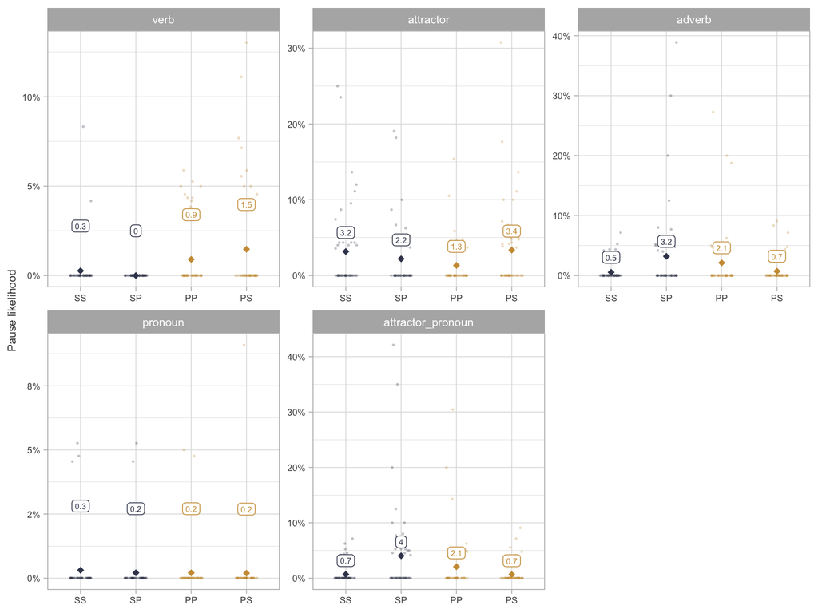

```r
average_pauses <- mutate(latencydata) %>%

  # Keep only pause data.
  filter(!is.na(Pause)) %>%

  # Compute averages by condition and segment.
  group_by(Segment, Condition) %>%
  dplyr::summarise(
    .groups = "keep",
    NPause = sum(Pause),
    N      = length(Pause),
    Mean   = NPause / N,
    CIlow  = as.numeric(binom.confint(NPause, N, methods = "agresti-coull")["lower"]),
    CIhigh = as.numeric(binom.confint(NPause, N, methods = "agresti-coull")["upper"]))


# Plotting parameters
jitter <- position_jitter(width = 0.2, height = 0, seed = 0)

# Plot
plot_pause <- latencydata %>%

  # Keep only pause data.
  filter(!is.na(Pause)) %>%

  # Compute mean durations by participant.
  group_by(Participant, Segment, Condition, AntecedentNumber) %>%
  summarise(.groups = "keep",
            NPause = sum(Pause),
            N      = length(Pause),
            Mean   = NPause / N) %>%

  # Add by-condition means to the data frame.
  group_by(Segment, Condition) %>%
  mutate(MeanCondition = mean(Mean, na.rm = TRUE)) %>%

  # Draw plot.
  {ggplot(., aes(x = Condition, y = Mean, color = AntecedentNumber)) +

      # Draw by-participant means.
      geom_point(size = 0.9, alpha = 0.3, stroke = 0, position = jitter) +

      # Draw group means and labels.
      stat_summary(fun = mean, geom ="point", shape = 18, size = 2) +
      geom_label(
        data = unique(dplyr::select(., c(Segment, Condition, MeanCondition, AntecedentNumber))),
        aes(x = Condition, y = MeanCondition, label = round(MeanCondition, 3) * 100),
        size = 2, nudge_y = 0.025, label.padding = unit(.15, "lines")) +

      # Facets for each segment.
      facet_wrap(. ~ Segment, ncol = 3, scales = "free") +

      # Customize axes and scales.
      labs(x = NULL, y = "Pause likelihood") +
      scale_color_manual(values = c("#3C425A", "#CC9A41")) +
      scale_x_discrete(labels = c("SS", "SP", "PP", "PS")) +
      scale_y_continuous(labels = scales::percent_format(accuracy = 1)) +

      # Customize theme.
      theme_light() +
      theme(legend.position = "none") +
      theme(text = element_text(size = 8, colour = "gray28")) +
      theme(strip.text.x = element_text(size = 8))
  }
plot_pause
```

```r
# Save plot.
# ggsave("./figures/pauses.jpeg", plot_pause, units = "cm", height = 10, width = 12, dpi = 300)
```

# 8 Contrasts

- AntecedentNumber: sum coded (-1 singular, +1 plural).
- Match: sum coded (-1 match, +1 mismatch)
- Structure: sum coded (-1 no_preposition, +1 with_preposition)

RK: The recommendation is the stay with digits.

```r
# contrasts for accuracy data
contrasts(accuracydata$AntecedentNumber) <- -contr.sum(2)
contrasts(accuracydata$Match)            <- -contr.sum(2)
contrasts(accuracydata$Structure)        <- -contr.sum(2)

# contrasts for latency data.
contrasts(latencydata$AntecedentNumber) <- -contr.sum(2)
contrasts(latencydata$Match)            <- -contr.sum(2)
contrasts(latencydata$Structure)        <- -contr.sum(2)
```

# 9 Check distribution

RK: I would recommend to do this much earlier. Possibly even before the outlier detection – unless they are clearly unreasonable.

The Box-Cox procedure is used to determine the best transformation (adapted from Osborne, 2010). + if 0 =< λ < 1, log transformation; + if -1 < λ < 0, reciprocal; + if λ = 1, no transformation needed.

RK: Hm?

# 10 Data transformation

## 10.1 Adverb + pronoun region

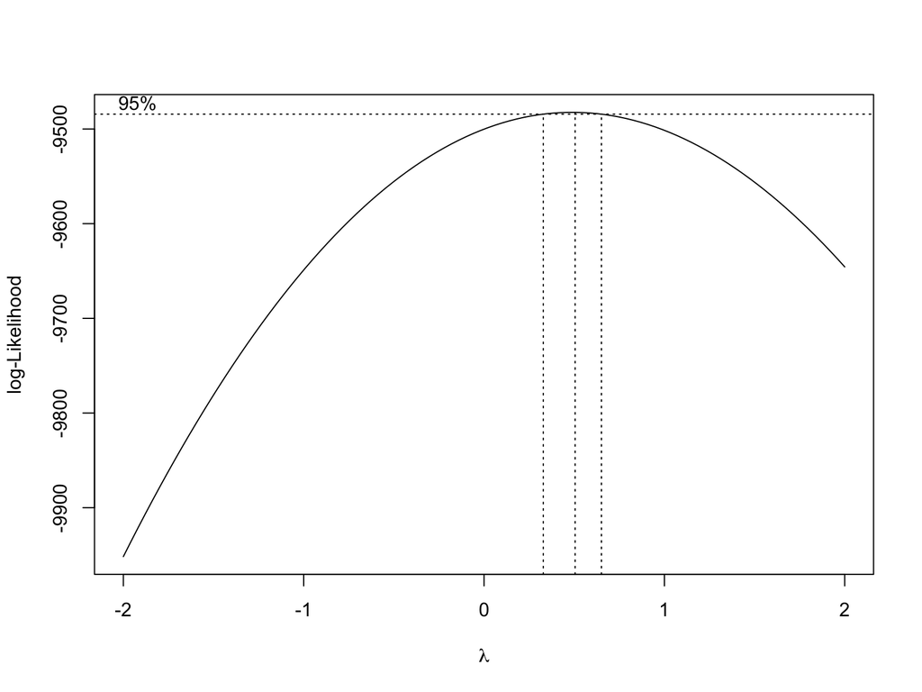

```r
bc <- boxcox(lm(Duration ~ 1, data = filter(latencydata, Segment == "attractor_pronoun")))
```

```r
bc <- data.frame(cbind(lambda = bc$x, lik = bc$y))
bc <- bc[bc$lik == max(bc$lik), "lambda"]
```

lambda = 0.51 so log transformation is used.

RK: Square-root would be an option, too.

## 10.2 Pronoun region

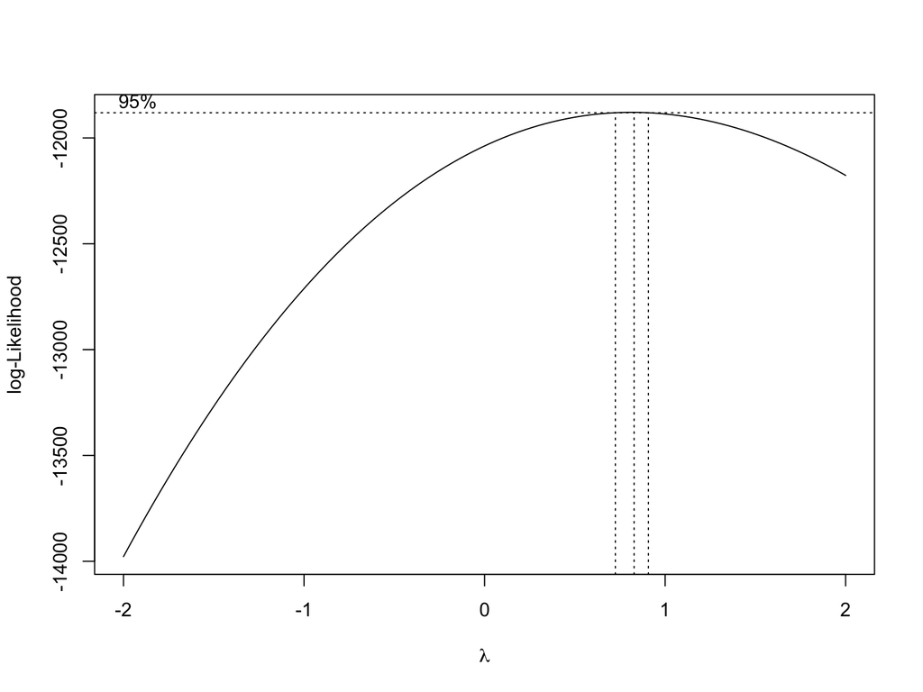

```r
bc <- boxcox(lm(Duration ~ 1, data = filter(latencydata, Segment == "pronoun")))
```

```r
bc <- data.frame(cbind(lambda = bc$x, lik = bc$y))
bc <- bc[bc$lik == max(bc$lik), "lambda"]
```

lambda = 0.83 so log transformation is used).

RK: I would not transform.

## 10.3 Onset region

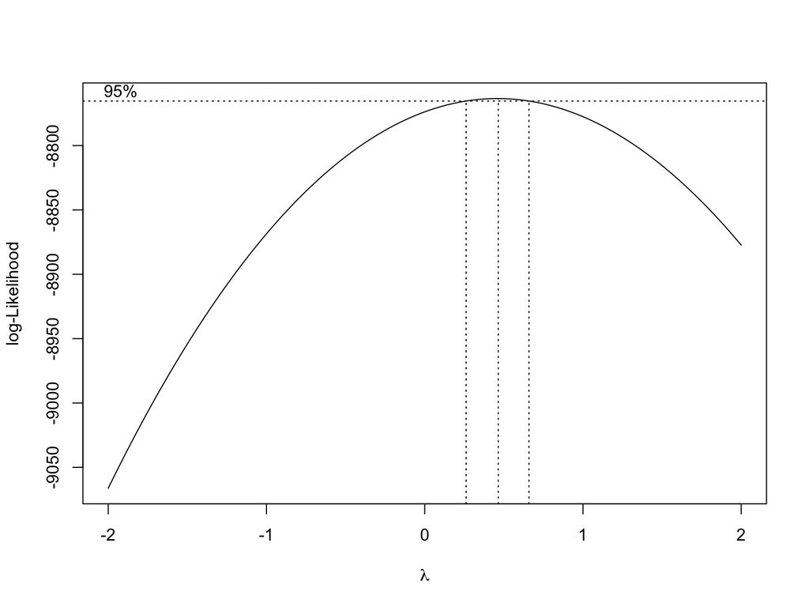

```r
bc <- boxcox(lm(Duration ~ 1, data = filter(latencydata, Segment == "onset")))
```

```r
bc <- data.frame(cbind(lambda = bc$x, lik = bc$y))
bc <- bc[bc$lik == max(bc$lik), "lambda"]
```

lambda = 0.47 so log transformation is used).

RK: Square-root would be an option, too.

RK: I definitely would not use different transformations for different regions. My impression is that staying with the original metric would be ok.

# 11 (G)LMMs

## 11.1 GLMM for accuracy: AntecedentNumber * Match

NB: Random effects simplified due to non-convergence) RK:

- The mpdel is not correctly specified. One problem is that you must not use factors with `||` in RES.
- The specification may cause false-positive convergence errors.
- Antecedent and Match look like within-Subject/Item factors.

[output not shown]

Here random effects were simplified due to non-convergence, but we may just as well start with the so-called maximal LMM.

```r
f1 <- "./fits/m_acc.rda"
if(!file.exists(f1)){
m_acc <- glmer(NumberError ~ 1 + AntecedentNumber * Match +
                            (1 + AntecedentNumber * Match | Participant) +
                            (1 + AntecedentNumber * Match | Item),
                    family = binomial,
                    data = accuracydata,
                    control = glmerControl(calc.derivs=FALSE))
save(m_acc, file=f1)
} else load(f1)

summary(rePCA(m_acc))
```

```
$Item
Importance of components:
                         [,1]   [,2]    [,3]    [,4]
Standard deviation     1.3724 0.9706 0.05705 0.02759
Proportion of Variance 0.6657 0.3329 0.00115 0.00027
Cumulative Proportion  0.6657 0.9986 0.99973 1.00000

$Participant
Importance of components:
                         [,1]   [,2]    [,3]    [,4]
Standard deviation     1.1118 0.6247 0.14893 0.02292
Proportion of Variance 0.7496 0.2366 0.01345 0.00032
Cumulative Proportion  0.7496 0.9862 0.99968 1.00000
```

```r
VarCorr(m_acc)
```

```
 Groups      Name                     Std.Dev. Corr
 Item        (Intercept)              0.80618
             AntecedentNumber1        0.87028  -0.524
             Match1                   0.78221  -0.974  0.338
             AntecedentNumber1:Match1 0.90023   0.318 -0.971 -0.112
 Participant (Intercept)              0.89646
             AntecedentNumber1        0.76636  -0.561
             Match1                   0.20289  -0.167  0.791
             AntecedentNumber1:Match1 0.46579   0.443 -0.961 -0.679
```

## 11.2 GLMM for accuracy: AntecedentNumber / Match

RK: A nested model may be a good a priori or post-hoc alternative LMM. Usually, it makes more sense to use the same formula in the fixed-effect and RES part of the LMM – if such a complex RES is supported by the data.

```r
f2 <- "./fits/m_acc_nested.rda"
if(!file.exists(f2)){
m_acc_nested <- glmer(NumberError ~ 1 + AntecedentNumber / Match +
                                   (1 + AntecedentNumber / Match | Participant) +
                                   (1 + AntecedentNumber / Match | Item),
                                   family = binomial,
                                   data = accuracydata,
                                   control = glmerControl(calc.derivs=FALSE))
save(m_acc_nested, file=f2)
} else load(f2)

summary(rePCA(m_acc_nested))
```

```
$Item
Importance of components:
                         [,1]   [,2]    [,3]    [,4]
Standard deviation     1.4042 0.9526 0.03146 0.01630
Proportion of Variance 0.6845 0.3150 0.00034 0.00009
Cumulative Proportion  0.6845 0.9996 0.99991 1.00000

$Participant
Importance of components:
                         [,1]   [,2]    [,3]    [,4]
Standard deviation     1.0521 0.6150 0.33061 0.02907
Proportion of Variance 0.6939 0.2371 0.06851 0.00053
Cumulative Proportion  0.6939 0.9310 0.99947 1.00000
```

```r
VarCorr(m_acc_nested)
```

```
 Groups      Name                            Std.Dev. Corr
 Item        (Intercept)                     0.61779
             AntecedentNumber1               0.72512  -0.653
             AntecedentNumbersingular:Match1 1.01865  -0.850  0.953
             AntecedentNumberplural:Match1   0.96718  -0.211 -0.602 -0.334
 Participant (Intercept)                     0.85080
             AntecedentNumber1               0.69106  -0.570
             AntecedentNumbersingular:Match1 0.43415  -0.221  0.914
             AntecedentNumberplural:Match1   0.45327   0.449 -0.605 -0.632
```

We do get convergence failure for the nested LMM. This strongly suggests that the first LMM may not be supported as well as it looks. We check with MixedModels.jl.

## 11.3 LMM for duration for adverb + pronoun region: AntecedentNumber * Match

RK: Similar problems with original LMM.

```
m_duration_nested <- lmer(log(Duration) ~  1 + Syllable +
                           AntecedentNumber + AntecedentNumber*Match
                          (1 + AntecedentNumber + AntecedentNumber:Match | Participant)
                          (1 + AntecedentNumber:Match || Item),
                          data = filter(latencydata, Segment == "attractor_pronoun"))
summary(m_duration_nested)
```

Again random effects were simplified due to non-convergence, but again we start with the so-called maximal LMM.

```r
f3 <- "./fits/m_dur.rda"
if(!file.exists(f3)){
m_dur <- lmer(log(Duration) ~ 1 + (Syllable) + AntecedentNumber * Match  +
                             (1 + AntecedentNumber + Match | Participant) +
                             (1 + AntecedentNumber + Match | Item),
                   data = filter(latencydata, Segment == "attractor_pronoun"),
                   REML=FALSE, control=lmerControl(calc.derivs=FALSE))
save(m_dur, file=f3)
} else load(f3)

summary(rePCA(m_dur))
```

```
$Item
Importance of components:
                         [,1]    [,2] [,3]
Standard deviation     0.1034 0.06366    0
Proportion of Variance 0.7250 0.27495    0
Cumulative Proportion  0.7250 1.00000    1

$Participant
Importance of components:
                         [,1]   [,2]    [,3]
Standard deviation     0.8617 0.2979 0.06146
Proportion of Variance 0.8892 0.1062 0.00452
Cumulative Proportion  0.8892 0.9955 1.00000
```

```r
VarCorr(m_dur)
```

```
 Groups      Name              Std.Dev.  Corr
 Item        (Intercept)       0.0093358
             AntecedentNumber1 0.0026851 -0.946
             Match1            0.0063700  0.273  0.053
 Participant (Intercept)       0.0822917
             AntecedentNumber1 0.0284157 -0.107
             Match1            0.0080785 -0.491 -0.411
 Residual                      0.0956802
```

Plot of main model residuals.

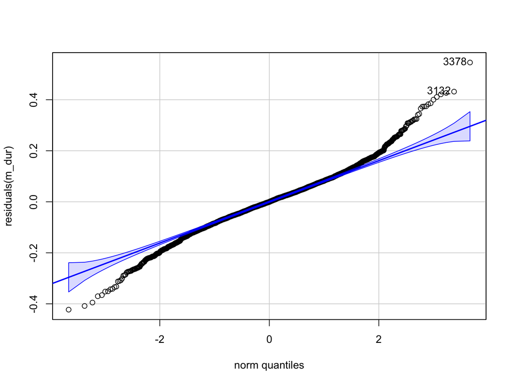

```
3378 3132
3277 3032
```

```r
qqPlot(residuals(m_dur))
```

They look fine.

## 11.4 LMM for duration for adverb + pronoun region: AntecedentNumber / Match

```r
f4 <- "./fits/m_dur_nested.rda"
if(!file.exists(f4)){
m_dur_nested <- lmer(log(Duration) ~ 1 + (Syllable) + AntecedentNumber / Match  +
                                    (1 + AntecedentNumber / Match | Participant) +
                                    (1 + AntecedentNumber / Match | Item),
                   data = filter(latencydata, Segment == "attractor_pronoun"),
                   REML=FALSE, control=lmerControl(calc.derivs=FALSE))
save(m_dur, file=f4)
} else load(f4)
```

```
boundary (singular) fit: see help('isSingular')
```

```r
#summary(rePCA(m_dur_nested))
#VarCorr(m_dur_nested)
```

Similar to crossed version of LMM:

## 11.5 GLMM for pauses before adverb + pronoun region: AntecedentNumber * Match

Original version with random effects simplified due to non-convergence.

```r
f5 <- "./fits/m_pause.rda"
if(!file.exists(f5)){
m_pause <- glmer(Pause ~ 1 + AntecedentNumber * Match +
                        (1 + AntecedentNumber * Match | Participant) +
                        (1 + Match | Item),
                        family = binomial,
                        data = filter(latencydata, Segment == "attractor_pronoun"),
                        control = glmerControl(calc.derivs=FALSE))
save(m_pause, file=f5)
} else load(f5)

summary(rePCA(m_pause))
```

```
$Item
Importance of components:
                         [,1]   [,2]
Standard deviation     0.9072 0.4985
Proportion of Variance 0.7681 0.2319
Cumulative Proportion  0.7681 1.0000

$Participant
Importance of components:
                         [,1]   [,2]    [,3]      [,4]
Standard deviation     1.4022 0.9857 0.43889 0.0008602
Proportion of Variance 0.6281 0.3104 0.06153 0.0000000
Cumulative Proportion  0.6281 0.9385 1.00000 1.0000000
```

```r
VarCorr(m_pause)
```

```
 Groups      Name                     Std.Dev. Corr
 Item        (Intercept)              0.68552
             Match1                   0.77564  -0.526
 Participant (Intercept)              1.33582
             AntecedentNumber1        0.50965   0.104
             Match1                   0.12568   0.301  0.775
             AntecedentNumber1:Match1 1.03464  -0.274 -0.508  0.050
```

```r
f6 <- "./fits/m_pause_nested.rda"
if(!file.exists(f6)){
m_pause_nested <- glmer(Pause ~ 1 + AntecedentNumber / Match +
                               (1 + AntecedentNumber / Match | Participant) +
                               (1 + Match | Item),
                               family = binomial,
                       data = filter(latencydata, Segment == "attractor_pronoun"),
                       control = glmerControl(calc.derivs=FALSE))
save(m_pause, file=f6)
} else load(f6)

summary(rePCA(m_pause_nested))
```

```
$Item
Importance of components:
                         [,1]   [,2]
Standard deviation     0.7985 0.6080
Proportion of Variance 0.6331 0.3669
Cumulative Proportion  0.6331 1.0000

$Participant
Importance of components:
                         [,1]   [,2]    [,3]      [,4]
Standard deviation     1.4445 1.2395 0.55961 0.0001121
Proportion of Variance 0.5301 0.3903 0.07956 0.0000000
Cumulative Proportion  0.5301 0.9204 1.00000 1.0000000
```

```r
VarCorr(m_pause_nested)
```

```
 Groups      Name                            Std.Dev. Corr
 Item        (Intercept)                     0.71426
             Match1                          0.70505  -0.266
 Participant (Intercept)                     1.26221
             AntecedentNumber1               0.53220   0.218
             AntecedentNumbersingular:Match1 0.91762   0.361  0.164
             AntecedentNumberplural:Match1   1.10352   0.001  0.269 -0.868
```

## 11.7 LMM for duration on pronoun region: AntecedentNumber * Match

Random effects simplified due to non-convergence.-

```r
m_duration_pronoun <- lmer((log(Duration)) ~ 1 + Syllable + AntecedentNumber * Match +
                                            (1 + AntecedentNumber + Match | Participant) +
                                            (1 + AntecedentNumber + Match | Item),
                           data = filter(latencydata, Segment == "pronoun"), REML=FALSE,
                           control = lmerControl(calc.derivs=FALSE))
```

```
boundary (singular) fit: see help('isSingular')
```

```r
summary(m_duration_pronoun)
```

```
Linear mixed model fit by maximum likelihood  ['lmerMod']
Formula: (log(Duration)) ~ 1 + Syllable + AntecedentNumber * Match + (1 +
    AntecedentNumber + Match | Participant) + (1 + AntecedentNumber +
    Match | Item)
   Data: filter(latencydata, Segment == "pronoun")
Control: lmerControl(calc.derivs = FALSE)

     AIC      BIC   logLik deviance df.resid
 -2696.8  -2583.1   1366.4  -2732.8     4072

Scaled residuals:
    Min      1Q  Median      3Q     Max
-5.1313 -0.5063  0.0382  0.5599  6.0924

Random effects:
 Groups      Name              Variance  Std.Dev. Corr
 Item        (Intercept)       4.436e-04 0.021063
             AntecedentNumber1 6.457e-05 0.008035 -1.00
             Match1            2.505e-05 0.005005 -0.74  0.74
 Participant (Intercept)       1.916e-02 0.138435
             AntecedentNumber1 2.893e-03 0.053783 -0.08
             Match1            1.655e-05 0.004068 -0.64 -0.71
 Residual                      2.748e-02 0.165756
Number of obs: 4090, groups:  Item, 112; Participant, 47

Fixed effects:
                          Estimate Std. Error t value
(Intercept)               5.019593   0.031980 156.960
Syllable                  0.318073   0.008950  35.540
AntecedentNumber1         0.079392   0.008617   9.213
Match1                    0.005965   0.002714   2.198
AntecedentNumber1:Match1 -0.008244   0.002607  -3.162

Correlation of Fixed Effects:
            (Intr) Syllbl AntcN1 Match1
Syllable    -0.768
AntcdntNmb1  0.149 -0.263
Match1      -0.102  0.010 -0.138
AntcdnN1:M1  0.004 -0.007  0.012  0.020
optimizer (nloptwrap) convergence code: 0 (OK)
boundary (singular) fit: see help('isSingular')
```

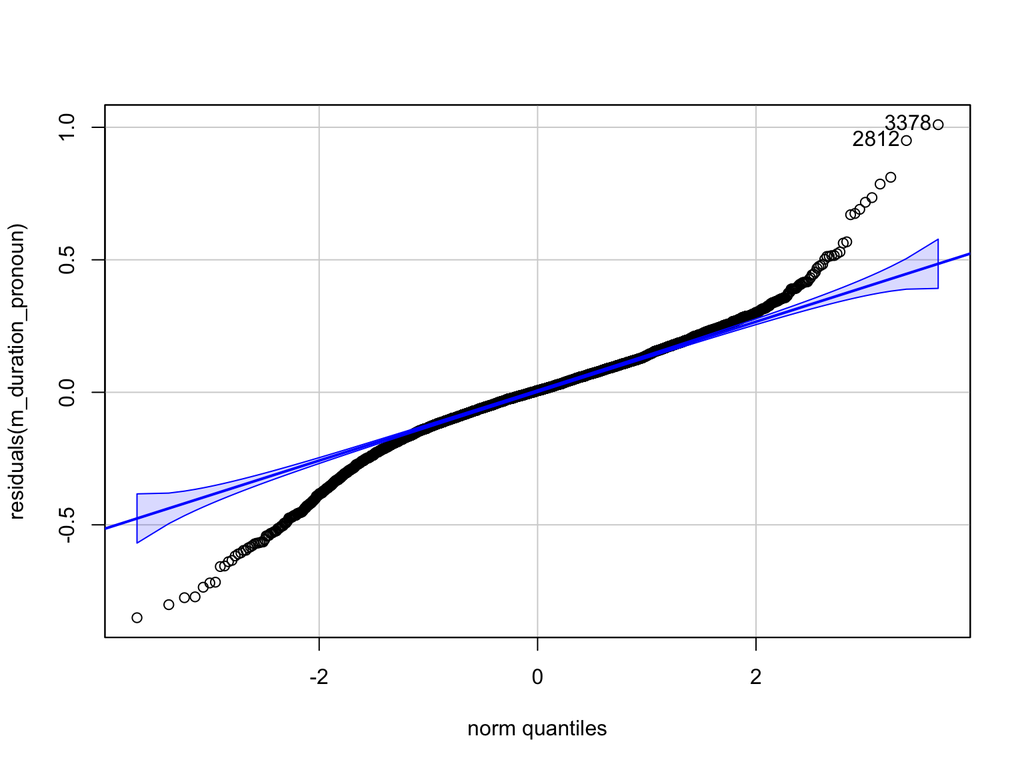

```
3378 2812
3325 2760
```

```r
qqPlot(residuals(m_duration_pronoun))
```

## 11.8 LMM for duration on pronoun region: AntecedentNumber / Match

Random effects simplified due to non-convergence.

```r
m_duration_pronoun_nested <- lmer((log(Duration)) ~ Syllable +
                                  + AntecedentNumber + AntecedentNumber:Match
                                  + (1 + AntecedentNumber + AntecedentNumber:Match | Participant)
                                  + (1 + AntecedentNumber:Match || Item),
                                  data = filter(latencydata, Segment == "pronoun"))
```

```
boundary (singular) fit: see help('isSingular')
```

```r
summary(m_duration_pronoun_nested)
```

```
Linear mixed model fit by REML ['lmerMod']
Formula:
(log(Duration)) ~ Syllable + +AntecedentNumber + AntecedentNumber:Match +
    (1 + AntecedentNumber + AntecedentNumber:Match | Participant) +
    ((1 | Item) + (0 + AntecedentNumber:Match | Item))
   Data: filter(latencydata, Segment == "pronoun")

REML criterion at convergence: -2799

Scaled residuals:
    Min      1Q  Median      3Q     Max
-5.4108 -0.4900  0.0279  0.5345  6.1572

Random effects:
 Groups      Name                                   Variance  Std.Dev.  Corr
 Item        AntecedentNumbersingular:Matchmatch    4.494e-04 2.120e-02
             AntecedentNumberplural:Matchmatch      1.096e-05 3.311e-03  1.00
             AntecedentNumbersingular:Matchmismatch 5.223e-04 2.285e-02 -0.22
             AntecedentNumberplural:Matchmismatch   2.339e-06 1.530e-03 -0.99
 Item.1      (Intercept)                            4.370e-12 2.090e-06
 Participant (Intercept)                            1.950e-02 1.396e-01
             AntecedentNumber1                      2.946e-03 5.428e-02 -0.07
             AntecedentNumbersingular:Match1        1.782e-03 4.221e-02 -0.17
             AntecedentNumberplural:Match1          8.721e-04 2.953e-02  0.11
 Residual                                           2.645e-02 1.626e-01



 -0.22
 -0.99  0.08



  0.06
 -0.21 -0.99

Number of obs: 4090, groups:  Item, 112; Participant, 47

Fixed effects:
                                 Estimate Std. Error t value
(Intercept)                      5.008490   0.029297 170.958
Syllable                         0.322131   0.007607  42.346
AntecedentNumber1                0.078796   0.008580   9.184
AntecedentNumbersingular:Match1  0.014337   0.007324   1.957
AntecedentNumberplural:Match1   -0.002276   0.005666  -0.402

Correlation of Fixed Effects:
                (Intr) Syllbl AntcN1 AntcdntNmbrs:M1
Syllable        -0.713
AntcdntNmb1      0.113 -0.226
AntcdntNmbrs:M1 -0.105  0.007  0.037
AntcdntNmbrp:M1  0.056 -0.001 -0.144 -0.628
optimizer (nloptwrap) convergence code: 0 (OK)
boundary (singular) fit: see help('isSingular')
```

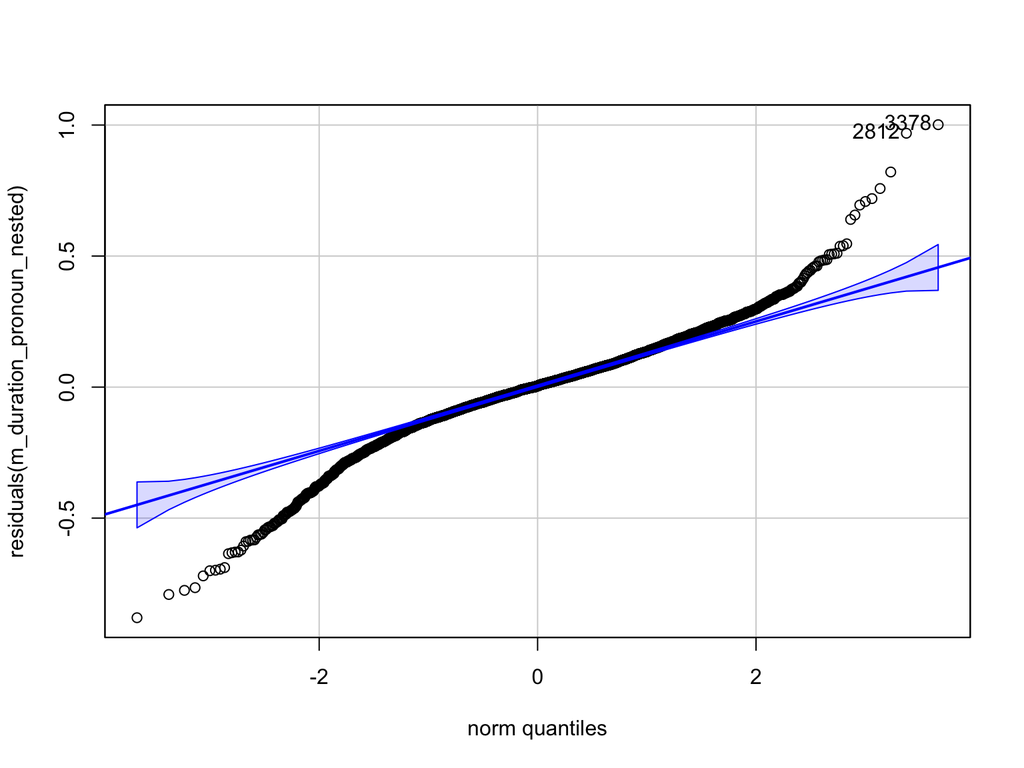

```
3378 2812
3325 2760
```

```r
qqPlot(residuals(m_duration_pronoun_nested))
```

# 12 Supplementary analysis: utterance onset latency —-

Random effects simplified due to non-convergence.

```r
m_duration_onset <- lmer(log(Duration) ~ AntecedentNumber * Match
                           + (1 + AntecedentNumber + Match | Participant)
                           + (1 + AntecedentNumber + Match | Item),
                           data = filter(latencydata, Segment == "onset"))
```

```
boundary (singular) fit: see help('isSingular')
```

```r
summary(m_duration_onset)
```

```
Linear mixed model fit by REML ['lmerMod']
Formula: log(Duration) ~ AntecedentNumber * Match + (1 + AntecedentNumber +
    Match | Participant) + (1 + AntecedentNumber + Match | Item)
   Data: filter(latencydata, Segment == "onset")

REML criterion at convergence: -7026.2

Scaled residuals:
    Min      1Q  Median      3Q     Max
-6.9424 -0.5362 -0.0496  0.5342  4.2238

Random effects:
 Groups      Name              Variance  Std.Dev. Corr
 Item        (Intercept)       2.465e-05 0.004964
             AntecedentNumber1 1.077e-05 0.003282  0.82
             Match1            3.695e-05 0.006079  0.09 -0.49
 Participant (Intercept)       9.801e-03 0.099001
             AntecedentNumber1 7.770e-05 0.008815 -0.30
             Match1            1.478e-05 0.003844  0.25 -0.28
 Residual                      9.550e-03 0.097723
Number of obs: 4041, groups:  Item, 112; Participant, 47

Fixed effects:
                           Estimate Std. Error t value
(Intercept)               7.4636950  0.0145338 513.540
AntecedentNumber1        -0.0011262  0.0020393  -0.552
Match1                    0.0007659  0.0017422   0.440
AntecedentNumber1:Match1 -0.0001813  0.0015437  -0.117

Correlation of Fixed Effects:
            (Intr) AntcN1 Match1
AntcdntNmb1 -0.181
Match1       0.084 -0.092
AntcdnN1:M1 -0.002  0.020  0.018
optimizer (nloptwrap) convergence code: 0 (OK)
boundary (singular) fit: see help('isSingular')
```

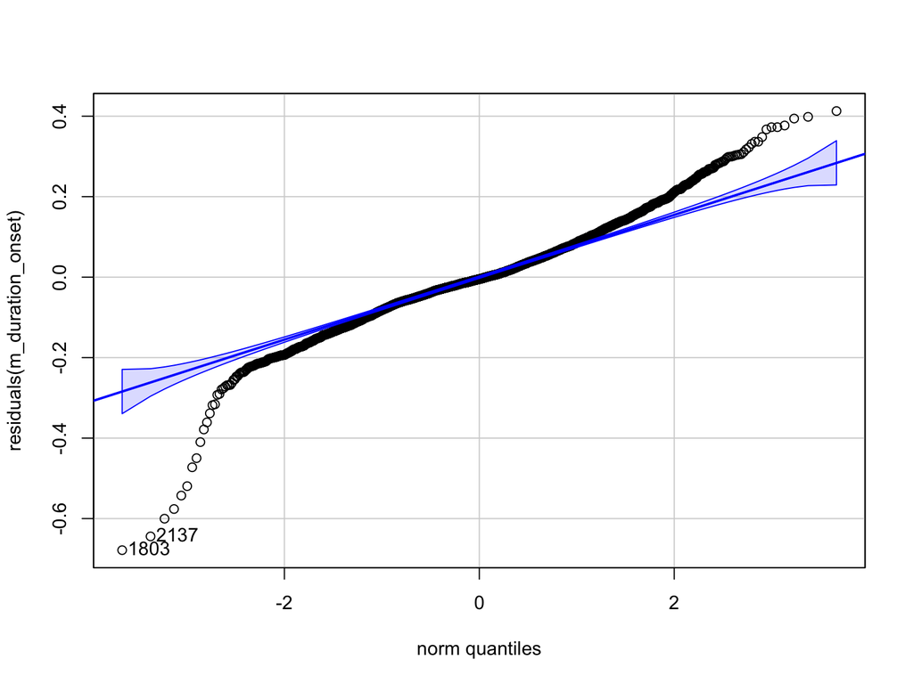

```
1803 2137
1771 2092
```

```r
qqPlot(residuals(m_duration_onset))
```

# 13 Supplementary analysis: effect of optional preposition

## 13.1 Plot durations by structure (boxplots)

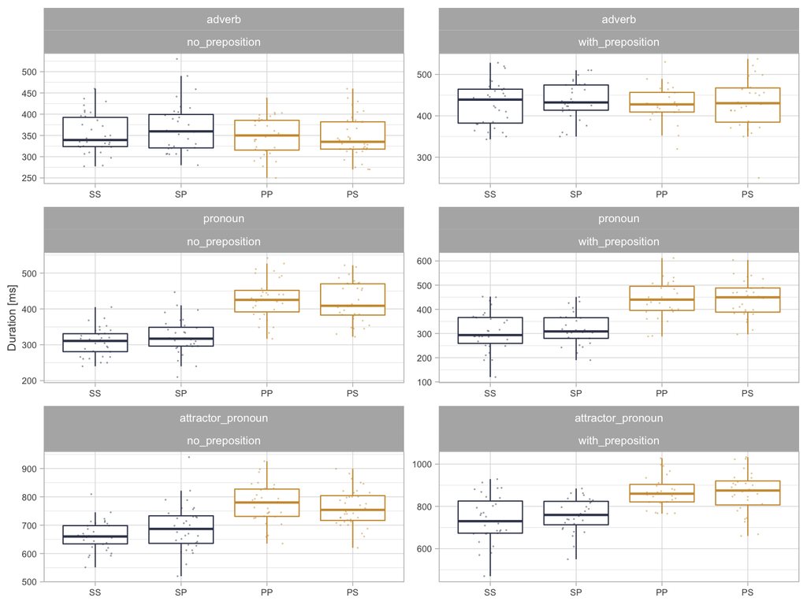

```r
# Plotting parameters
jitter <- position_jitter(width = 0.2, height = 0, seed = 0)

# Plot
plot_duration_boxplots_byStructure <- latencydata %>%

  # Keep only regions after the attractor
  filter(Segment %in% c("adverb", "pronoun", "attractor_pronoun")) %>%

  # Compute mean durations by participant.
  group_by(Participant, Segment, Condition, AntecedentNumber, Structure) %>%
  summarise(.groups = "keep", Mean = mean(Duration, na.rm = TRUE)) %>%

  # Draw plot.
  {ggplot(., aes(x = Condition, y = Mean, color = AntecedentNumber)) +

      # Draw boxplots.
      geom_boxplot(size = 0.4, outlier.shape = NA, na.rm = TRUE) +

      # Draw by-participant means.
      geom_point(size = 0.6, alpha = 0.5, stroke = 0, position = jitter, na.rm = TRUE) +

      # Facets for each segment and structure.
      facet_wrap(Segment ~ Structure, ncol = 2, scales = "free") +

      # Customize axes and scales.
      labs(x = NULL, y = "Duration [ms]") +
      scale_color_manual(values = c("#3C425A", "#CC9A41")) +
      scale_x_discrete(labels = c("SS", "SP", "PP", "PS")) +

      # Customize theme.
      theme_light() +
      theme(legend.position = "none") +
      theme(text = element_text(size = 8, colour = "gray28")) +
      theme(strip.text.x = element_text(size = 8))
  }
plot_duration_boxplots_byStructure
```

```r
# Save plot.
#ggsave("durations_critical_boxplots_byStructure.jpeg",
#       plot_duration_boxplots_byStructure,
#       units = "cm", height = 15, width = 10, dpi = 300)
```

## 13.2 Plot durations by structure (noodleplots)

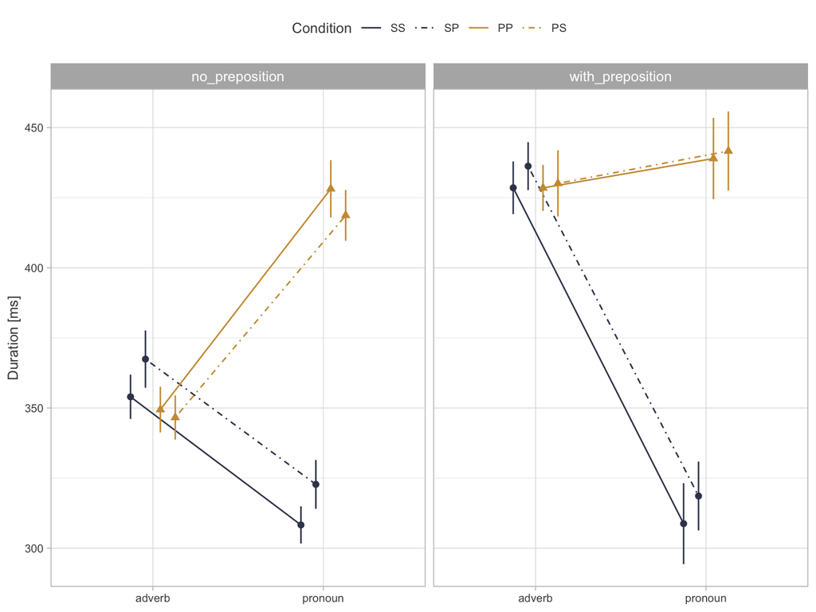

```r
# Plotting parameters.
jitter        <- position_jitter(width = 0.2, height = 0, seed = 0)
dodge         <- position_dodge(0.35)
color_cond    <- c("#3C425A", "#3C425A", "#CC9A41", "#CC9A41")
shape_cond    <- c(16, 16, 17, 17)
linetype_cond <- c("solid", "dotdash", "solid", "dotdash")
label_cond    <- toupper(levels(latencydata$Condition))
label_regions <- c("adverb","pronoun")

# Plot.
plot_duration_noodle_byStructure <- latencydata %>%

  # Exclude utterance onset.
  filter(Segment %in% c("adverb", "pronoun")) %>%

  # Compute mean durations by participant.
  group_by(Participant, Structure, Segment, Condition, AntecedentNumber, Match) %>%
  summarise(.groups = "keep", Mean = mean(Duration, na.rm = TRUE)) %>%

  # Draw plot.
  {ggplot(., aes(x = Segment, y = Mean, group = Condition, color = Condition)) +

      # Plot by-condition means and standard error bars.
      stat_summary(fun = mean, geom = "path", aes(linetype = Condition),
                   size = 0.5, position = dodge, na.rm = TRUE)  +
      stat_summary(fun.data = mean_se, geom = "errorbar", size = 0.5,
                   width = 0, position = dodge, show.legend = FALSE, na.rm = TRUE) +
      stat_summary(fun = mean, geom = "point", aes(shape = Condition),
                   size = 2, position = dodge, show.legend = FALSE, na.rm = TRUE)  +

      # Facets for each segment.
      facet_wrap(. ~ Structure) +

      # Customize axes and scales.
      labs(x = NULL, y = "Duration [ms]") +
      scale_x_discrete(labels = label_regions) +
      scale_color_manual(values = color_cond, labels = label_cond) +
      scale_shape_manual(values = shape_cond, labels = label_cond) +
      scale_linetype_manual(values = linetype_cond, labels = label_cond) +

      # Customize theme.
      theme_light() +
      theme(legend.position = "top") +
      theme(text = element_text(size = 10, colour = "gray28")) +
      theme(strip.text.x = element_text(size = 10))
}
plot_duration_noodle_byStructure
```

```r
# Save plot.
#ggsave("durations_critical_noodle_byStructure.jpeg",
#       plot_duration_noodle_byStructure,
#       units = "cm", height = 7, width = 9, dpi = 300)
```

# 14 LMM models

## 14.1 Adverb + pronoun region: Structure * AntecedentNumber * Match

Random effects simplified due to non-convergence

```r
# Compute model (random effects simplified due to non-convergence).
m_duration_strucure <-
  lmer(log(Duration) ~ Structure * AntecedentNumber * Match
       + (1 + Structure + AntecedentNumber + Match | Participant)
       + (1 + Structure + AntecedentNumber + Match | Item),
       data = filter(latencydata, Segment == "attractor_pronoun"))
```

```
boundary (singular) fit: see help('isSingular')
```

```r
# Print main model summary.
summary(m_duration_strucure)
```

```
Linear mixed model fit by REML ['lmerMod']
Formula:
log(Duration) ~ Structure * AntecedentNumber * Match + (1 + Structure +
    AntecedentNumber + Match | Participant) + (1 + Structure +
    AntecedentNumber + Match | Item)
   Data: filter(latencydata, Segment == "attractor_pronoun")

REML criterion at convergence: -6868.1

Scaled residuals:
    Min      1Q  Median      3Q     Max
-4.4374 -0.5821 -0.0026  0.5678  5.7559

Random effects:
 Groups      Name              Variance  Std.Dev. Corr
 Item        (Intercept)       1.514e-03 0.038909
             Structure1        5.880e-05 0.007668 -0.32
             AntecedentNumber1 9.425e-04 0.030700 -0.99  0.46
             Match1            4.871e-05 0.006979  0.42  0.15 -0.37
 Participant (Intercept)       5.632e-03 0.075047
             Structure1        1.071e-03 0.032723  0.32
             AntecedentNumber1 8.362e-04 0.028918 -0.12  0.13
             Match1            7.381e-05 0.008591 -0.30 -0.96 -0.40
 Residual                      8.988e-03 0.094808
Number of obs: 4041, groups:  Item, 112; Participant, 47

Fixed effects:
                                      Estimate Std. Error t value
(Intercept)                          6.6320474  0.0122428 541.711
Structure1                           0.0553281  0.0073169   7.562
AntecedentNumber1                    0.0660554  0.0053580  12.328
Match1                               0.0047389  0.0020930   2.264
Structure1:AntecedentNumber1         0.0005687  0.0032162   0.177
Structure1:Match1                    0.0006784  0.0018725   0.362
AntecedentNumber1:Match1            -0.0089477  0.0015345  -5.831
Structure1:AntecedentNumber1:Match1 -0.0020666  0.0015904  -1.299

Correlation of Fixed Effects:
            (Intr) Strct1 AntcN1 Match1 St1:AN1 St1:M1 AN1:M1
Structure1   0.283
AntcdntNmb1 -0.242  0.093
Match1      -0.128 -0.382 -0.249
Strctr1:AN1  0.043  0.047  0.057  0.039
Strctr1:Mt1 -0.150 -0.126  0.004  0.097 -0.210
AntcdnN1:M1 -0.005  0.018  0.011  0.023 -0.008   0.023
Str1:AN1:M1  0.003 -0.042 -0.001  0.017  0.032  -0.030  0.126
optimizer (nloptwrap) convergence code: 0 (OK)
boundary (singular) fit: see help('isSingular')
```

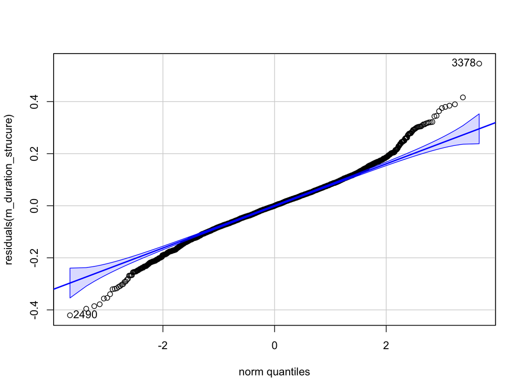

```
3378 2490
3277 2419
```

```r
# Plot main model residuals.
qqPlot(residuals(m_duration_strucure))
```

## 14.2 Adverb + pronoun region: Structure + AntecedentNumber / Match

```r
m_duration_structure_nested <-
  lmer(log(Duration) ~  Structure + AntecedentNumber/Match +
       + (1 + Structure + AntecedentNumber + AntecedentNumber:Match | Participant)
       + (1 + Structure + AntecedentNumber:Match || Item),
       data = filter(latencydata, Segment == "attractor_pronoun"))
```

```
boundary (singular) fit: see help('isSingular')
```

```r
summary(m_duration_structure_nested)
```

```
Linear mixed model fit by REML ['lmerMod']
Formula:
log(Duration) ~ Structure + AntecedentNumber/Match + +(1 + Structure +
    AntecedentNumber + AntecedentNumber:Match | Participant) +
    ((1 | Item) + (0 + Structure | Item) + (0 + AntecedentNumber:Match |
        Item))
   Data: filter(latencydata, Segment == "attractor_pronoun")

REML criterion at convergence: -7068.7

Scaled residuals:
    Min      1Q  Median      3Q     Max
-4.9003 -0.5636  0.0015  0.5636  5.7980

Random effects:
 Groups      Name                                   Variance  Std.Dev. Corr
 Item        AntecedentNumbersingular:Matchmatch    4.673e-03 0.068359
             AntecedentNumberplural:Matchmatch      3.842e-05 0.006198 1.00
             AntecedentNumbersingular:Matchmismatch 5.427e-03 0.073667 0.93
             AntecedentNumberplural:Matchmismatch   1.032e-04 0.010158 0.96
 Item.1      Structureno_preposition                0.000e+00 0.000000
             Structurewith_preposition              1.312e-04 0.011454  NaN
 Item.2      (Intercept)                            0.000e+00 0.000000
 Participant (Intercept)                            5.973e-03 0.077288
             Structure1                             7.386e-04 0.027177  0.21
             AntecedentNumber1                      8.311e-04 0.028829 -0.11
             AntecedentNumbersingular:Match1        9.103e-04 0.030172 -0.30
             AntecedentNumberplural:Match1          3.132e-04 0.017697  0.20
 Residual                                           8.425e-03 0.091786



 0.93
 0.96  0.99





  0.12
 -0.43 -0.51
 -0.05  0.46 -0.88

Number of obs: 4041, groups:  Item, 112; Participant, 47

Fixed effects:
                                 Estimate Std. Error t value
(Intercept)                      6.633383   0.012330 537.999
Structure1                       0.053806   0.006542   8.225
AntecedentNumber1                0.066076   0.005330  12.397
AntecedentNumbersingular:Match1  0.013657   0.005046   2.707
AntecedentNumberplural:Match1   -0.003494   0.003350  -1.043

Correlation of Fixed Effects:
                (Intr) Strct1 AntcN1 AntcdntNmbrs:M1
Structure1       0.190
AntcdntNmb1     -0.239  0.057
AntcdntNmbrs:M1 -0.221 -0.234 -0.386
AntcdntNmbrp:M1  0.163 -0.011  0.253 -0.587
optimizer (nloptwrap) convergence code: 0 (OK)
boundary (singular) fit: see help('isSingular')
```

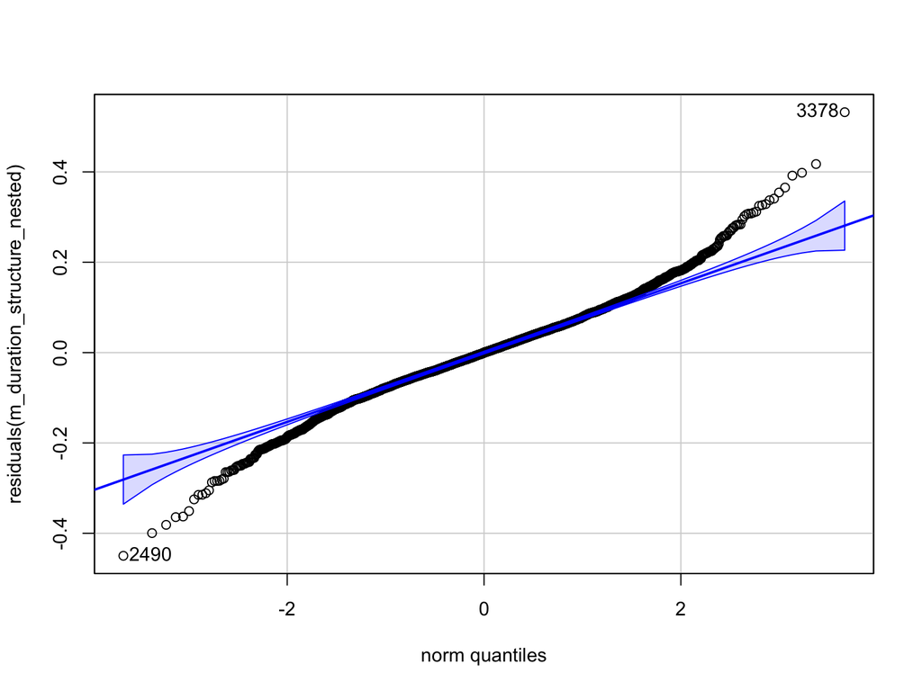

```
3378 2490
3277 2419
```

```r
qqPlot(residuals(m_duration_structure_nested))
```

# 15 Supplementary analysis: density plots for durations

## 15.1 Density plots by region

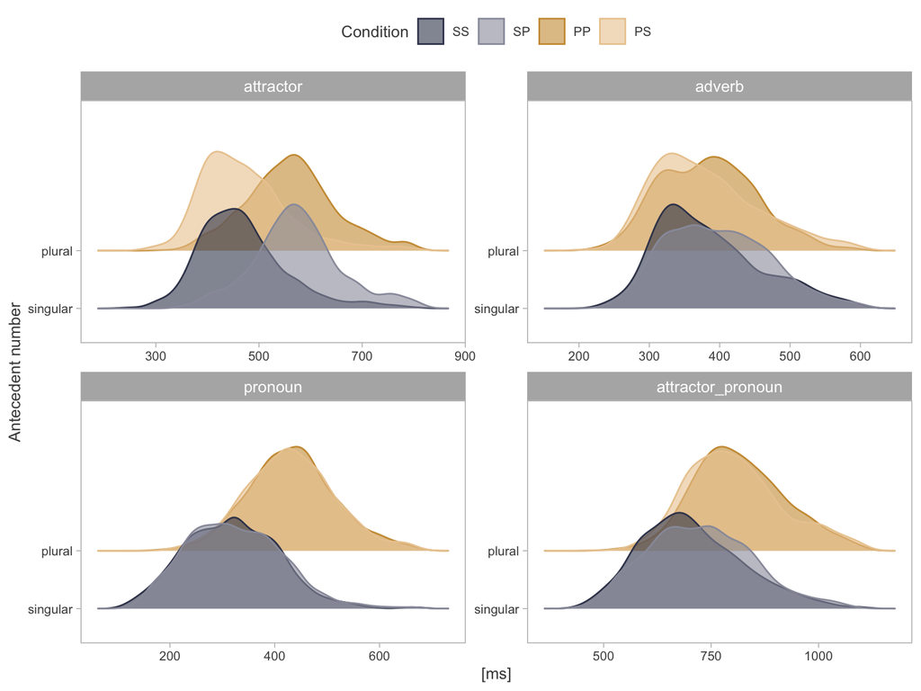

```r
# Plotting parameters.
color_cond <- c("#3C425A", "#999ba9", "#CC9A41", "#ebcb9f")
fill_cond  <- c("#3C425A", "#999ba9", "#CC9A41", "#ebcb9f")
label_cond <- toupper(levels(latencydata$Condition))

# Plot.
plot_density_by_region <- latencydata %>%

  # Compute mean durations by participant.
  group_by(Participant, Segment, Condition, AntecedentNumber, Match) %>%

  # Select regions.
  filter(Segment %in% c("attractor", "adverb", "pronoun", "attractor_pronoun")) %>%

  # Make condition labels capitals.
  mutate(Condition = factor(toupper(Condition), levels = c("SS", "SP", "PP", "PS"))) %>%

  # Draw plot.
  {ggplot(., aes(x = Duration, y = AntecedentNumber, color = Condition, fill = Condition)) +

      # Draw boxplots.
      geom_density_ridges(alpha = 0.6, na.rm = TRUE) +

      # Facets for each segment.
      facet_wrap(. ~ Segment, ncol = 2, scales = "free") +

      # Customize axes and scales.
      labs(x = "[ms]", y = "Antecedent number") +
      coord_cartesian(ylim = c(1, 4)) +
      scale_fill_manual(values = fill_cond, labels = label_cond) +
      scale_color_manual(values = color_cond, labels = label_cond) +
      guides(fill = guide_legend(override.aes = list(shape = 16, size = 0.5))) +

      # Customize theme.
      theme_light() +
      theme(panel.grid.major = element_blank()) +
      theme(panel.grid.minor = element_blank()) +
      theme(legend.text = element_text(size = 8), legend.position = "top") +
      theme(text = element_text(size = 10, colour = "gray28")) +
      theme(strip.text.x = element_text(size = 10))
  }
plot_density_by_region
```

```r
# Save plot.
#ggsave("density_by_region.jpeg", plot_density_by_region ,
#       units = "cm", height = 10, width = 16, dpi = 300)
```

## 15.2 Density plots by structure

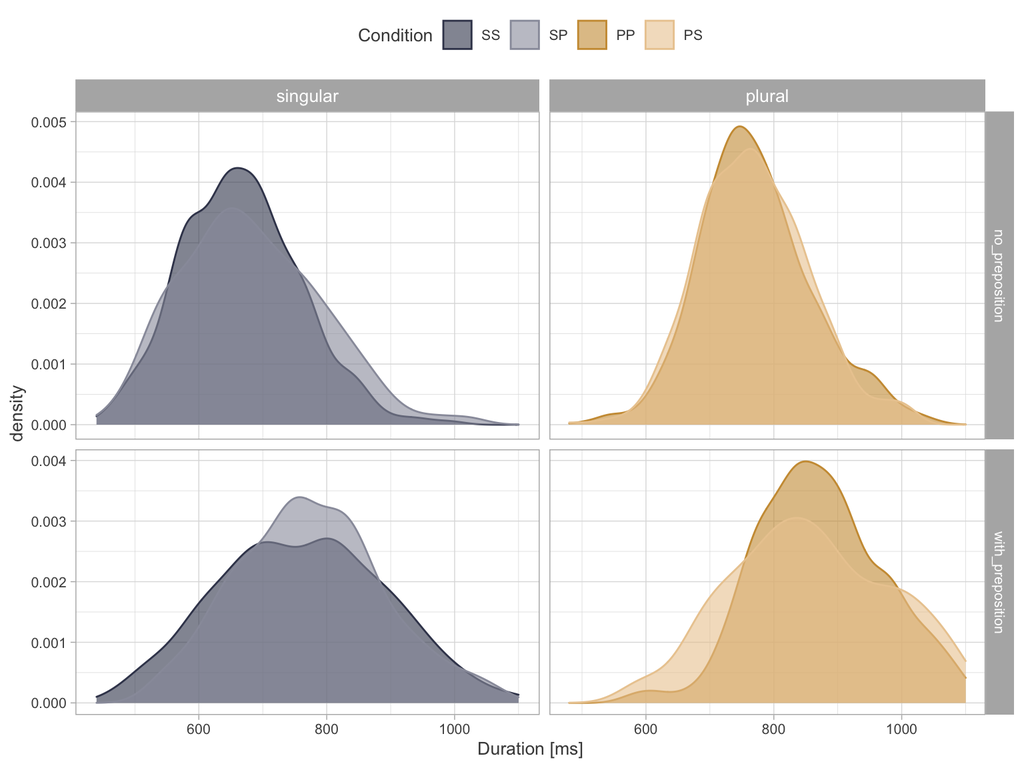

```r
# Plotting parameters.
color_cond <- c("#3C425A", "#999ba9", "#CC9A41", "#ebcb9f")
fill_cond  <- c("#3C425A", "#999ba9", "#CC9A41", "#ebcb9f")
label_cond <- toupper(levels(latencydata$Condition))

# Plot.
plot_density_critical_byStructure <- latencydata %>%

  # Compute mean durations by participant.
  group_by(Participant, Segment, Condition, AntecedentNumber) %>%

  filter(Segment == "attractor_pronoun") %>%

  # Draw plot.
  {ggplot(., aes(x = Duration, color = Condition, fill = Condition)) +

      # Draw boxplots.
      geom_density(alpha = 0.6, na.rm = TRUE) +

      # Facets for each segment.
      facet_grid(Structure ~ AntecedentNumber, scales = "free", space = "free") +

      # Customize axes and scales.
      labs(x = "Duration [ms]") +
      scale_fill_manual(values = fill_cond, labels = label_cond) +
      scale_color_manual(values = color_cond, labels = label_cond) +
      scale_linetype_manual(values = linetype_cond, labels = label_cond) +

      # Customize theme.
      theme_light() +
      theme(legend.position = "top") +
      theme(text = element_text(size = 10, colour = "gray28")) +
      theme(strip.text.x = element_text(size = 10))
  }
plot_density_critical_byStructure
```

```r
# Save plot.
# ggsave("density_postattractor_byStructure.jpeg", plot_density_critical_byStructure,
#         units = "cm", height = 12, width = 16, dpi = 300)
```

# 16 Supplementary analysis: vincentile plots for durations

## 16.1 Select participants

Participants with fewer observations than the desired number of vincentiles are excluded on a by-condition basis.

```r
vincentile_exclude <- mutate(latencydata) %>%

  # Select regions of interest.
  filter(Segment %in% c("attractor", "adverb", "pronoun", "attractor_pronoun")) %>%
  droplevels() %>%

  # Keep only relevant columns.
  dplyr::select(c("Participant", "Condition","Segment","Duration")) %>%
  distinct(.keep_all = TRUE) %>%

  # Group by participant, condition and region.
  group_by(Segment, Participant, Condition) %>%

  # Count number of observations by group.
  summarise(Count = length(Duration), .groups = "drop") %>%
  mutate(KeepForVincentile = factor(ifelse(Count < N_VINCENTILES, "no", "yes")))
```

## 16.2 Compute vincentiles

Apply exclusions, select regions/factors of interest and exclude NAs.

```r
vincentiles <-

  # Do data exclusions.
  left_join(latencydata, vincentile_exclude)  %>%
  filter(KeepForVincentile == "yes")  %>%
  filter(Segment %in% c("attractor", "adverb", "pronoun", "attractor_pronoun")) %>%
  filter(!is.na(Duration)) %>%
  droplevels() %>%

  # Select relevant columns.
  dplyr::select(c("Segment", "Participant", "Item", "Condition",
                  "AntecedentNumber", "Match", "Duration")) %>%
  distinct(.keep_all = TRUE) %>%

  # Assign observations to equally-populated bins.
  # [FIXME]: the bins don't seem equally populated!
  group_by(Segment, Participant, Condition, AntecedentNumber, Match) %>%
  mutate(Bin = bin(Duration, nbins = N_VINCENTILES, method = "content")) %>%

  # Compute mean duration per bin.
  group_by(Segment, Participant, Condition, AntecedentNumber, Match, Bin) %>%
  arrange(Segment, Participant, Condition, AntecedentNumber, Match, Duration) %>%
  mutate(BinMean = mean(Duration)) %>%

  # Get rid of unused columns.
  dplyr::select(-c("Item", "Duration")) %>%
  distinct(.keep_all = TRUE) %>%

  # Sort data frame by bin number.
  group_by(Segment, Participant, Condition, AntecedentNumber, Match) %>%
  mutate(BinNumber = order(BinMean)) %>%
  droplevels()
```

## 16.3 Plot

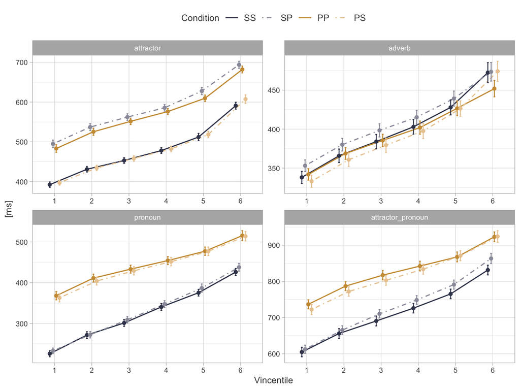

```r
# Parameters
dodge         <- position_dodge(0.35)
color_cond    <- c("#3C425A", "#999ba9", "#CC9A41", "#ebcb9f")
linetype_cond <- c("solid", "dotdash", "solid", "dotdash")

plot_vincentiles <-

  # Draw vincentiles.
  ggplot(vincentiles, aes(x = factor(BinNumber), y = BinMean,
                          group = Condition, colour = Condition)) +
  stat_summary(fun = mean, geom = "path", aes(linetype = Condition),
               size = 0.6, position = dodge) +
  stat_summary(fun.data = mean_se, geom = "errorbar", width = 0.2,
               size = 0.5, position = dodge, show.legend = FALSE) +
  stat_summary(fun = mean, geom = "point", size = 1.5,
               position = dodge, show.legend = FALSE) +

  # Use different facets for each segment.
  facet_wrap(. ~ Segment, ncol = 2, scales = "free") +

  # Customize axes and scales.
  labs(x = "Vincentile", y = "[ms]") +
  scale_x_discrete(labels = c(1:N_VINCENTILES)) +
  scale_colour_manual(values = color_cond, labels = label_cond) +
  scale_linetype_manual(values = linetype_cond, labels = label_cond) +

  # Customize theme.
  theme_light() +
  theme(text = element_text(size = 10, colour = "gray28")) +
  theme(legend.position = "top") +
  theme(legend.title = element_text(size = 10), legend.text = element_text(size = 10))

plot_vincentiles
```

```r
# Save plot.
# ggsave("vincentiles.jpeg", plot_vincentiles, units = "cm",
#       height = 12, width = 16, dpi = 300)
```

# 17 RK: Save dataframes for transfer to Julia

```r
library(arrow)
dat_acc <-
  accuracydata |>
  as_tibble() |>
  dplyr::select(Subj=Participant, Item, Condition, Match, ACN=AntecedentNumber, nerr=NumberError) |>
  mutate(
    Subj = factor(paste0("S", str_pad(str_remove(Subj, "s"), width = 2, side = "left", pad = "0"))),
    Item = factor(paste0("I", str_pad(Item, width = 3, side = "left", pad = "0"))))
write_feather(dat_acc, "./data/Bahmanian_acc.arrow")

dat_dur <-
  latencydata |>
  as_tibble() |>
  dplyr::select(Subj=Participant, Item, Condition, Match, ACN=AntecedentNumber, Segment, dur=Duration, pause=Pause) |>
  mutate(
    Subj = factor(paste0("S", str_pad(str_remove(Subj, "s"), width = 2, side = "left", pad = "0"))),
    Item = factor(paste0("I", str_pad(Item, width = 3, side = "left", pad = "0"))))
write_feather(dat_dur, "./data/Bahmanian_dur.arrow")
```

# 18 Appendix